# Esercitazione N.3

Author

Econometria

# Nonlinearità

**Pacchetti necessari:**

```r
library(tidyverse)
library(knitr)
library(kableExtra)
library(modelsummary)
library(fixest)
```

**Per i dati:**

```r
library(wooldridge)
```

```r
data("wage1", package = "wooldridge")
```

```r
reg_wage <- feols(wage ~ educ, data = wage1, vcov = "hetero")
```

Le trasformazioni logaritmiche permettono di modellare le relazioni in termini “percentuali” invece che lineari.

Una specificazione alternativa potrebbe essere: ogni anno di istruzione aumenta i salari di una percentuale:

Consideriamo:

$$log(wage_i) = \beta_0 + \beta_1 educ_i + u_i$$

E stimiamo:

```r
reg_logwage <- feols(log(wage) ~ educ, data = wage1, vcov = "hetero")
```

Prendendo l’esponenziale si scrive:
$$wage_i = exp(\beta_0 + \beta_1 educ_i + u_i)$$

**Nota:** Qui abbiamo anche $exp^{u_{i}}$. Stiamo assumendo per ragioni didattiche che sia uguale a zero per mostrarlo graficamente. La questione di come calcolare le previsioni di $Y$ quando abbiamo $log(Y)$ è discussa nel paragrafo 8.2 di Stock e Watson (pp. 215-216).

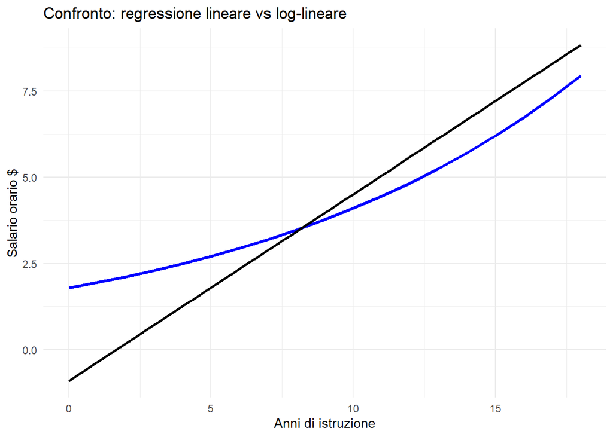

```r
# Previsione valori stimati dal modello log-lineare
wage1 <- wage1 %>%
  mutate(
    logwage_pred = predict(reg_logwage),    #valori predetti in log
    wage_pred = exp(logwage_pred)           #salario predetto in scala originale
  )

# Grafico con curva log-lineare + retta OLS
ggplot(wage1, aes(x = educ)) +
  geom_line(aes(y = wage_pred), color = "blue", size = 1.2) +          # curva log-lineare
  geom_smooth(aes(y = wage), method = "lm", se = FALSE, color = "black", size = 1) + # retta OLS
  labs(
    title = "Confronto: regressione lineare vs log-lineare",
    x = "Anni di istruzione",
    y = "Salario orario $"
  ) +
  theme_minimal()
```

```r
modelsummary(list("Wage" = reg_wage, "Log Wage" = reg_logwage), output = "markdown", gof_omit = "AIC|BIC|RMSE|R2 Adj.")
```

|  | Wage | Log Wage |
| --- | --- | --- |
| (Intercept) | -0.905 | 0.584 |
|  | (0.725) | (0.098) |
| educ | 0.541 | 0.083 |
|  | (0.061) | (0.008) |
| Num.Obs. | 526 | 526 |
| R2 | 0.165 | 0.186 |
| Std.Errors | Heteroskedasticity-robust | Heteroskedasticity-robust |

Il coefficiente $\beta_1$ ha una interpretazione in termini percentuali una volta moltiplicato per 100.

In media, un anno aggiuntivo di istruzione è associato ad un aumento del salario orario ($wage$) del’8.3%

$R^2$ mostra che $educ$ spiega circa il 18.6% della variazione in log($wage$) (no $wage$). $R^2$ non può essere usato per confrontare queste due regressioni perché hanno variabile dipendente diversa ($wage$ e log($wage$), vedete Stock e Watson p. 215).

I logaritmi possono essere usati per trasformare la variabile dipendente $Y$, una variabile indipendente $X$ e entrambe (devono essere positive). Interpretazione del coefficiente $\beta_1$

### Specificazioni in log

**Specificazioni in log**

| Forma del modello | Interpretazione |
| --- | --- |
| $\log(Y)$ ~ $X$ | Un’unità in più in $X$ determina una variazione di $100 \cdot \beta_1$% in $Y$ |
| $Y$ ~ $\log(X)$ | Un aumento dell’1% in $X$ determina una variazione di $0{,}01 \cdot \beta_1$ in $Y$ |
| $\log(Y)$ ~ $\log(X)$ | Un aumento dell’1% in $X$ determina una variazione di $\beta_1$% in $Y$ |

**3 casi con wage e educ:**

```r
reg_wagelog <- feols(wage ~ log(educ), data = wage1, vcov = "hetero")
reg_logwagelog <- feols(lwage ~ log(educ), data = wage1, vcov = "hetero")
modelsummary(list("Log Wage" = reg_logwage, "Wage" = reg_wagelog, "Log Wage" =reg_logwagelog), output = "markdown", gof_omit = "AIC|BIC|RMSE|R2 Adj.")
```

|  | Log Wage | Wage | Log Wage |
| --- | --- | --- | --- |
| (Intercept) | 0.584 | -7.460 | -0.445 |
|  | (0.098) | (1.863) | (0.268) |
| educ | 0.083 |  |  |
|  | (0.008) |  |  |
| log(educ) |  | 5.330 | 0.825 |
|  |  | (0.757) | (0.106) |
| Num.Obs. | 526 | 524 | 524 |
| R2 | 0.186 | 0.128 | 0.149 |
| Std.Errors | Heteroskedasticity-robust | Heteroskedasticity-robust | Heteroskedasticity-robust |

- **Primo modello:** (log-level): Ad ogni anno in più di istruzione è associato in media un aumento dell’8.3 % del salario orario.
- **Secondo modello:** (level-log): Un aumento del 1% degli anni di istruzione è associato ad un aumento, in media, del salario orario di 0.053 dollari. In modo equivalente un aumento del 10% degli anni di istruzione è associato ad un aumento, in media, il salario orario di 0.53$ (10 $\cdot$ 0.053).
- **Terzo modello:** (log-log): Un aumento dell’ 1% degli anni di istruzione è associato ad un aumento, in media, del salario orario dello 0.825 %.

La scelta della specificazione (forma funzionale) dev’essere guidata dal ragionamento – quale interpretazione ha più senso?

I logaritmi sono spesso utilizzati quando la variabile è in dollari (ad esempio wage o income) o variabili come popolazione (in particolare quando c’è abbastanza variazione).

Sono meno usati per variabili misurate in anni o che sono già percentuali o proporzioni (ad esempio tasso di disoccupazione).

**Unità di misura della variabile dipendente**

Con le variabili espresse in log, il cambiamento di unità di misura è irrilevante. Provate ad esprimere in salario in centinaia di dollari creando $wage$/100 e fate la regressione su $educ$. Lo stesso vale se la $X$ e $Y$ sono entrambe in log. L’intercetta invece cambierà.

### Interpretazione dummy e log:

Esempio finale dell’Esercitazione 2 con $wage$ espresso in log e dummy con categorie mutliple.

Costruiamo le seguenti dummy:

```r
wage1 <- wage1 %>%
  mutate(
    marrmale = ifelse(female == 0 & married == 1, 1, 0),
    marrfemale = ifelse(female == 1 & married == 1, 1, 0),
    singfem = ifelse(female == 1 & married == 0, 1, 0)
  )
```

```r
reg_logwage_dummy <- feols(log(wage) ~ marrmale + marrfemale + singfem + educ + exper + tenure, data = wage1, vcov = "hetero")
modelsummary(list("Log Wage" = reg_logwage_dummy), output = "markdown", gof_omit = "AIC|BIC|RMSE")
```

|  | Log Wage |
| --- | --- |
| (Intercept) | 0.388 |
|  | (0.117) |
| marrmale | 0.292 |
|  | (0.057) |
| marrfemale | -0.120 |
|  | (0.059) |
| singfem | -0.097 |
|  | (0.060) |
| educ | 0.084 |
|  | (0.008) |
| exper | 0.003 |
|  | (0.002) |
| tenure | 0.016 |
|  | (0.003) |
| Num.Obs. | 526 |
| R2 | 0.424 |
| R2 Adj. | 0.417 |
| Std.Errors | Heteroskedasticity-robust |

Ricordiamo:

- le dummy si interpretano rispetto alla categoria omessa (uomini single)
- la variabile dipendente è in log (log($wage$))

Quindi i coefficienti delle tre dummy misurano la differenza (percentuale) in $wage$ relativamente agli uomini single.

- Gli uomini sposati ($marrmale$) guadagnano in media il 29.2 % in più rispetto agli uomini single, a parità di anni di istruzione, anni di esperienza e anni con lo stesso datore di lavoro.
- Le donne sposate guadagnano in media il 12% in meno rispetto agli uomini single, a parità di anni di istruzione, anni di esperienza e anni con lo stesso datore di lavoro.
- Le donne single guadagnano in media il 9.7% in meno rispetto agli uomini single, a parità di anni di istruzione, anni di esperienza e anni con lo stesso datore di lavoro.

### Campus Crime

`campus` contiene dati su 97 college e università. $crime$ rappresenta il numero annuale di crimini nel college e $enroll$ il numero di iscritti.

```r
data("campus", package = "wooldridge")
```

**Esercizio**

Potete provare a fare un po’ di statistiche descrittive

```r
reg_log_crime <- feols(log(crime) ~ log(enroll), data = campus, vcov = "hetero")
reg_log_crime2 <- feols(log(crime) ~ log(enroll) + log(police), data = campus, vcov = "hetero")
modelsummary(list("Log Crime" = reg_log_crime, "Log Crime" = reg_log_crime2 ), output = "markdown", gof_omit = "AIC|BIC|RMSE|R2 Adj.")
```

|  | Log Crime | Log Crime |
| --- | --- | --- |
| (Intercept) | -6.631 | -4.794 |
|  | (1.391) | (1.390) |
| log(enroll) | 1.270 | 0.923 |
|  | (0.142) | (0.171) |
| log(police) |  | 0.516 |
|  |  | (0.153) |
| Num.Obs. | 97 | 97 |
| R2 | 0.585 | 0.632 |
| Std.Errors | Heteroskedasticity-robust | Heteroskedasticity-robust |

**Coefficienti:** - Un aumento del’1% degli iscritti è associato ad un aumento in media dei crimini del 1.27% (se gli iscritti aumentassero del 2%?)

- A parità di poliziotti, un aumento del 1% degli iscritti è associato ad un aumento dei crimini dello 0.92%.

**Limiti della regressione:** Non stiamo considerando altri fattori. Potrebbe essere il caso che più alte iscrizioni sono correlate con altri fattori che causano maggior crimine: università più grandi possono essere in città più grandi con più alto crimini.

## Polinomi:

Siamo interessati agli effetti degli anni di esperienza sul salario orario ($wage$). il polinomio quadratico è spesso utilizzaro in applicazioni economiche per catturare effetti marginali crescenti e decrescenti.

```r
reg_wage_exper <- feols(wage ~ exper + I(exper^2), data = wage1, vcov = "hetero")
reg_wage_exper
```

```
OLS estimation, Dep. Var.: wage
Observations: 526
Standard-errors: Heteroskedasticity-robust
             Estimate Std. Error  t value   Pr(>|t|)
(Intercept)  3.725406   0.251918 14.78819  < 2.2e-16 ***
exper        0.298100   0.038927  7.65787 9.2072e-14 ***
I(exper^2)  -0.006130   0.000810 -7.57059 1.6915e-13 ***
---
Signif. codes:  0 '***' 0.001 '**' 0.01 '*' 0.05 '.' 0.1 ' ' 1
RMSE: 3.51427   Adj. R2: 0.0893
```

In questo caso $\beta_1$ è positivo e $\beta_2$ negativo.

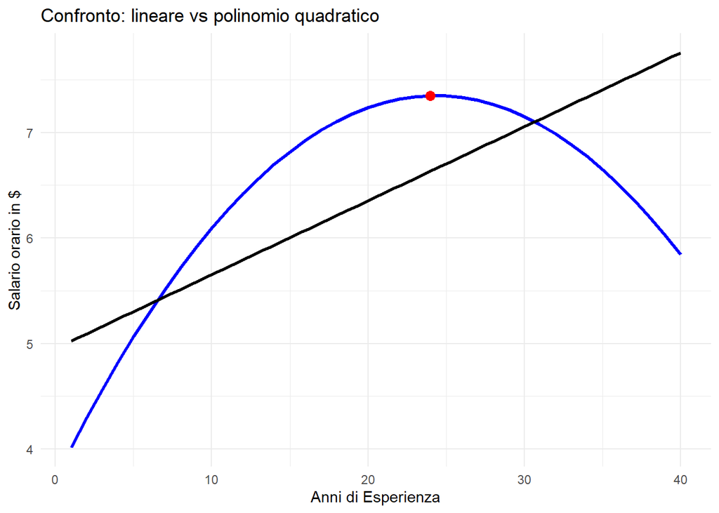

```r
# 1. Previsione dei valori stimati
wage1 <- wage1 %>%
  mutate(wageexp_pred = predict(reg_wage_exper))

# 2. Filtro per esper ≤ 40
wage_cut <- wage1 %>% filter(exper <= 40)

# 3. Trova il punto massimo della curva wageexp_pred
punto_max <- wage_cut %>%
  filter(wageexp_pred == max(wageexp_pred, na.rm = TRUE))

# 4. Grafico
ggplot(wage_cut, aes(x = exper)) +
  geom_line(aes(y = wageexp_pred), color = "blue", size = 1.2) +              # curva stimata
  geom_smooth(aes(y = wage), method = "lm", se = FALSE, color = "black", size = 1) + # retta OLS
  geom_point(data = punto_max, aes(y = wageexp_pred), color = "red", size = 3) +
  labs(
    title = "Confronto: lineare vs polinomio quadratico",
    x = "Anni di Esperienza",
    y = "Salario orario in $"
  ) +
  theme_minimal()
```

```r
reg_wage_exper2 <- feols(wage ~ exper + I(exper^2) + educ + tenure, data = wage1, vcov = "hetero")
modelsummary(list("Wage" = reg_wage_exper, "Wage" = reg_wage_exper2), output = "markdown", gof_omit = "AIC|BIC|RMSE|R2 Adj.")
```

|  | Wage | Wage |
| --- | --- | --- |
| (Intercept) | 3.725 | -3.420 |
|  | (0.252) | (0.780) |
| exper | 0.298 | 0.205 |
|  | (0.039) | (0.032) |
| I(exper^2) | -0.006 | -0.004 |
|  | (0.001) | (0.001) |
| educ |  | 0.556 |
|  |  | (0.059) |
| tenure |  | 0.161 |
|  |  | (0.028) |
| Num.Obs. | 526 | 526 |
| R2 | 0.093 | 0.343 |
| Std.Errors | Heteroskedasticity-robust | Heteroskedasticity-robust |

### Interpretazione dei coefficienti del primo modello:

Non possiamo interpretare il coefficiente associato a $\beta_1$ tenendo costante quello associato a $\beta_2$.

**Primo modello:** Consideriamo la variazione nel salario nel caso si passi da 1 a 2 anni di esperienza.

$$\Delta \hat{Y} = (\beta_0 + \beta_1 * 1 - \beta_2 * 1^{2}) - (\beta_0 + \beta_1 * 2 - \beta_2 * 2^{2})$$

Uguale a $4.297 - 4.017 = 0.28$ dollari

Ora considerando da 10 a 11 anni di esperienza:

- *10 anni*: $3.725 + 2.98 - 0.006 (100)$
- *11 anni*: $3.725 + 3.278 - 0.006 (121)$ $\Delta \hat{Y} = 6.277 - 6.105 = 0.172$ dollari

### Log e polinomi:

E se $wage$ fosse espresso in log?

```r
reg_logwage_exper <- feols(log(wage) ~ exper + I(exper^2), data = wage1, vcov = "hetero")
modelsummary(list("Wage" = reg_wage_exper, "Log Wage" = reg_logwage_exper), output = "kableExtra", gof_omit = "AIC|BIC|RMSE|R2 Adj.")
```

|  | Wage | Log Wage |
| --- | --- | --- |
| (Intercept) | 3.725 | 1.295 |
|  | (0.252) | (0.045) |
| exper | 0.298 | 0.046 |
|  | (0.039) | (0.006) |
| I(exper^2) | −0.006 | −0.001 |
|  | (0.001) | (0.000) |
| Num.Obs. | 526 | 526 |
| R2 | 0.093 | 0.104 |
| Std.Errors | Heteroskedasticity-robust | Heteroskedasticity-robust |

**Secondo modello (log):** Consideriamo la variazione nel salario predetto nel caso si passi da 10 a 11 anni di esperienza.

- *10 anni*: $1.295 + 0.046(10) - 0.001 (10)^{2}$ = 1.655
- *11 anni* = $1.295 + 0.046(11) - 0.001 (11)^{2}$ = 1.68

$\Delta \hat{Y} = 1.68 - 1.655 = 0.025$ cioè **2.5%**

**Esercizio**

Calcolate da 2 a 3 anni di esperienza